# Marketing_Analytics_Project

# Market Basket Analysis for E-commerce Transaction Data

Retailers use bundling or promotion mechanisms to hit their sales target but most of the time it is up to discussion to align on how much of the sales was incremental because of action taken. Customer level basket data analysis can reveal that which products are sold frequently together and which bundle or promotion mechanisms can increase sales etc.

We will use Apriori algorithm which is widely preffered one as it has 3 easy to understand and robust metrics; Support: shows how popular the item is (proportion of item’s appearance in all baskets) Confidence: If item X is already purchased, what’s the probability of buying Y as well? Lift: Correlation between item X and item Y

At the end of the study, aim is to have data-driven insight on frequently bought together items and then designing promotion or bundling plans accordingly.

## Exploratary Data Analysis

First, we need to load all required packages and the ones we will use in basket analysis algorithm.

```r
library(lubridate)
library(plyr)
library(dplyr)
library(arules)
library(arulesViz)
library(readxl)
library(ggplot2)
library(knitr)
library(tidyverse)
```

### Data Pre-processing

Our dataset includes transactions from UK based e-commerce business. It serves to different countries. The time interval is between December 1th, 2010 and December 9th, 2011.

```r
#read excel into R dataframe
basket <- read_csv('C:/Users/ugurcan.kalenderoglu/Desktop/BDA/Marketing_Analytics/data.csv')
str(basket)
```

```
## Classes 'spec_tbl_df', 'tbl_df', 'tbl' and 'data.frame': 541909 obs. of  8 variables:
##  $ InvoiceNo  : chr  "536365" "536365" "536365" "536365" ...
##  $ StockCode  : chr  "85123A" "71053" "84406B" "84029G" ...
##  $ Description: chr  "WHITE HANGING HEART T-LIGHT HOLDER" "WHITE METAL LANTERN" "CREAM CUPID HEARTS COAT HANGER" "KNITTED UNION FLAG HOT WATER BOTTLE" ...
##  $ Quantity   : num  6 6 8 6 6 2 6 6 6 32 ...
##  $ InvoiceDate: chr  "12/1/2010 8:26" "12/1/2010 8:26" "12/1/2010 8:26" "12/1/2010 8:26" ...
##  $ UnitPrice  : num  2.55 3.39 2.75 3.39 3.39 7.65 4.25 1.85 1.85 1.69 ...
##  $ CustomerID : num  17850 17850 17850 17850 17850 ...
##  $ Country    : chr  "United Kingdom" "United Kingdom" "United Kingdom" "United Kingdom" ...
##  - attr(*, "spec")=
##   .. cols(
##   ..   InvoiceNo = col_character(),
##   ..   StockCode = col_character(),
##   ..   Description = col_character(),
##   ..   Quantity = col_double(),
##   ..   InvoiceDate = col_character(),
##   ..   UnitPrice = col_double(),
##   ..   CustomerID = col_double(),
##   ..   Country = col_character()
##   .. )
```

We have 8 different columns which give: invoice number, item description, quantities included in the same invoice, price, unique id for each customer and origin country of given order.

We should drop the rows which are incomplete, to prepare the data to feed the algorithm without getting error.

```r
#Frist remove rows which include NAs
basket <- basket[complete.cases(basket), ]
```

We can also check the split of countries in terms of total number of baskets. So we can have knowledge on which shopping profile will dominate the results.

```r
#Group all invoices by country, count them and sort in descending order (show only top 6)
basket %>%
  group_by(Country) %>%
  summarise(TotOrder = n_distinct(InvoiceNo)) %>%
  arrange(desc(TotOrder)) %>%
  top_n(n = 6, wt = TotOrder)
```

```
## # A tibble: 6 x 2
##   Country        TotOrder
##   <chr>             <int>
## 1 United Kingdom    19857
## 2 Germany             603
## 3 France              458
## 4 EIRE                319
## 5 Belgium             119
## 6 Spain               105
```

United Kingdom is the top country by far in terms of order number as we would expect since the company is UK based. So we should keep in mind that the relationship between items will be based on shopping behaviour of British people.

We’re also interested in profile of shoppers. How frequent are they shopping from this e-reatiler? Simple histogram chart would give a good idea on that.

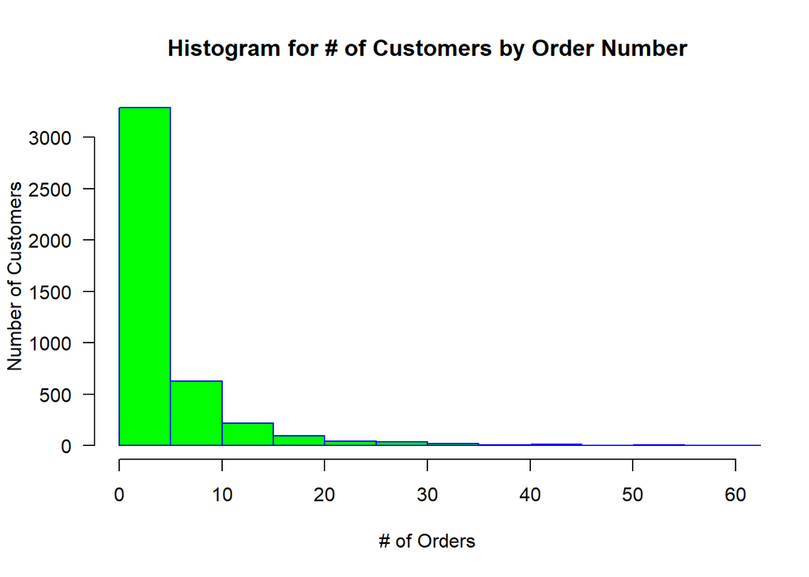

```r
#Group invoices by customerID and count only distinct InvoiceNos
customers <- basket %>%
              group_by(CustomerID) %>%
              summarise(TotOrder = n_distinct(InvoiceNo)) %>%
              arrange(desc(TotOrder))

#Plot histogram of it
hist(customers$TotOrder, main="Histogram for # of Customers by Order Number",
     xlab="# of Orders",
     ylab = 'Number of Customers',
     border="blue",
     col="green",
     xlim=c(0,60), las=1, breaks=40)
```

## Apply Apriori Algorithm

Arules package make it easy to implement apriori algoirthm which discover the relevant relationships between itemsets. It also enable us to set the threshold values for support, confidence and lift. So you have a chance to eliminate irrelevant or weak rules.

```r
#We need to convert data frame into class of 'transaction' as arules accepts only transaction type of data
transactions <- ddply(basket,c("InvoiceNo","InvoiceDate"),
                       function(df1)paste(df1$Description,
                       collapse = ","))
#InvoiceNo and Date will not be used in the rest of the study
transactions$InvoiceNo <- NULL
transactions$InvoiceDate <- NULL
```

```r
#Read the data as transaction
write.csv(transactions,"C:/Users/ugurcan.kalenderoglu/Desktop/BDA/Marketing_Analytics/data2.csv", quote= FALSE, row.names = FALSE)
transactions2 <- read.transactions('C:/Users/ugurcan.kalenderoglu/Desktop/BDA/Marketing_Analytics/data2.csv', format = 'basket', sep=',')
```

Which Items Appeared in the Baskets Most?

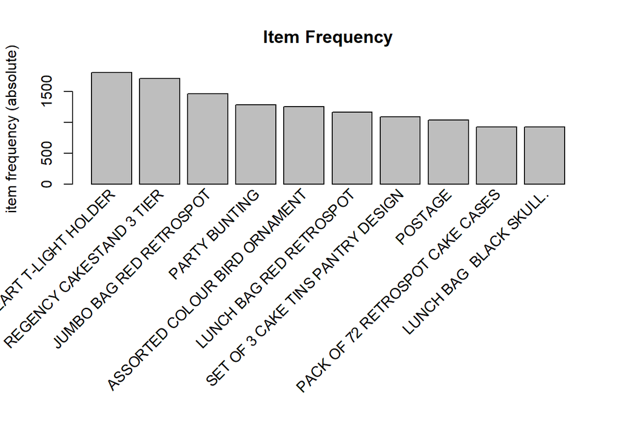

```r
#Plot item frequency chart for top 10
itemFrequencyPlot(transactions2, topN=10, type="absolute", main="Item Frequency")
```

There are some items which are included in the baskets most frequently such as T-light holder, cakestand and jumbo bag red retrospot.

```r
# Create rules and set min support as 0.001, confidence as 0.75.
association.rules <- apriori(transactions2, parameter = list(supp=0.001, conf=0.75,maxlen=10))
```

```
## Apriori
##
## Parameter specification:
##  confidence minval smax arem  aval originalSupport maxtime support minlen
##        0.75    0.1    1 none FALSE            TRUE       5   0.001      1
##  maxlen target   ext
##      10  rules FALSE
##
## Algorithmic control:
##  filter tree heap memopt load sort verbose
##     0.1 TRUE TRUE  FALSE TRUE    2    TRUE
##
## Absolute minimum support count: 22
##
## set item appearances ...[0 item(s)] done [0.00s].
## set transactions ...[7875 item(s), 22222 transaction(s)] done [0.13s].
## sorting and recoding items ... [2326 item(s)] done [0.01s].
## creating transaction tree ... done [0.00s].
## checking subsets of size 1 2 3 4 5 6 7 8 9 10 done [0.21s].
## writing ... [61534 rule(s)] done [0.02s].
## creating S4 object  ... done [0.04s].
```

```r
#Show first 10 rules as an example
inspect(association.rules[1:10])
```

```
##      lhs                               rhs                                support confidence     lift count
## [1]  {WOBBLY CHICKEN}               => {DECORATION}                   0.001260013  1.0000000 444.4400    28
## [2]  {WOBBLY CHICKEN}               => {METAL}                        0.001260013  1.0000000 444.4400    28
## [3]  {DECOUPAGE}                    => {GREETING CARD}                0.001035010  1.0000000 389.8596    23
## [4]  {BILLBOARD FONTS DESIGN}       => {WRAP}                         0.001305013  1.0000000 716.8387    29
## [5]  {WRAP}                         => {BILLBOARD FONTS DESIGN}       0.001305013  0.9354839 716.8387    29
## [6]  {ENAMEL PINK TEA CONTAINER}    => {ENAMEL PINK COFFEE CONTAINER} 0.001395014  0.8157895 385.7122    31
## [7]  {LANDMARK FRAME COVENT GARDEN} => {LANDMARK FRAME OXFORD STREET} 0.001485015  0.7857143 396.8214    33
## [8]  {LANDMARK FRAME OXFORD STREET} => {LANDMARK FRAME COVENT GARDEN} 0.001485015  0.7500000 396.8214    33
## [9]  {WOBBLY RABBIT}                => {DECORATION}                   0.001530015  1.0000000 444.4400    34
## [10] {WOBBLY RABBIT}                => {METAL}                        0.001530015  1.0000000 444.4400    34
```

You see two sections: lhs and rhs. Let’s go over the first row: Whenever the ‘Wobbly chicken’ is purchased, ‘decoration’ was also purchased 100% of time (confidence). Also, ‘wobbly chicken’ and ‘decoration’ are almost 444 times more likely to be purchased together compared to the case where they are independent items.

We can also visualize the output in a fancy way.

```r
# Filter rules with support greater than 0.13% and plot
subRules<-association.rules[quality(association.rules)$support>0.0013]
top10subRules <- head(subRules, n = 10, by = "confidence")
plot(top10subRules, method = "graph",  engine = "htmlwidget")
```

[interactive chart not shown]

You can read the output as following: Rule 8 says it’s likely to sell ‘swiss roll towel’ if customer already purchased ‘chocolate spots’. Now we know that there are some level of relationship and we can offer promotion or bundle chocolate spots to swiss roll towel customers to increase the sales.

### Take-Away Message

As we do in all data analytics application in business, output of market basket analysis should be evaluated from business perspective as well. It would not be realistic to offer item Y all the times when confidence and lift are high for item X shoppers.

Lastly, if the data is big enough and there a thousands of unique items then it would be hard to extract strong insight with high level of support threshold. So parameteres should be set based on the magnitude of the data and business domain knowledge.